# Progressive circle packing

Michael Bedward

2018-09-18

The function `circleProgressiveLayout` arranges a set of circles deterministically. The first two circles are placed to the left and right of the origin respectively. Subsequent circles are placed so that each:

- is externally tangent to two previously placed circles;
- does not overlap another circle;
- and is as close as possible to the origin.

The algorithm was described in the paper: *Visualization of large hierarchical data by circle packing* by Weixin Wang, Hui Wang, Guozhong Dai, and Hongan Wang. Published in *Proceedings of the SIGCHI Conference on Human Factors in Computing Systems*, 2006, pp. 517-520. [ACM](https://dl.acm.org/citation.cfm?id=1124851).

The implementation in this package is based on a [version written in C by Peter Menzel](https://github.com/pmenzel/packCircles).

The algorithm is very efficient and this, combined with the implementation in Rcpp, means arrangements for large numbers of circles can be found quickly.

## First example

We begin by arranging 10 circles of various sizes. First we pass a vector of circle areas to the `circleProgressiveLayout` function. It returns a data frame of centre coordinates and radii.

```r
areas <- c(20, 10, 40, rep(5, 7))

# Generate the layout
packing <- circleProgressiveLayout(areas)

head( round(packing, 2) )
```

```
##       x     y radius
## 1 -2.52  0.00   2.52
## 2  1.78  0.00   1.78
## 3  0.61 -5.22   3.57
## 4  0.22  2.61   1.26
## 5  2.72  2.90   1.26
## 6  4.59  1.19   1.26
```

Next we derive a data frame of circle vertices for plotting using the `circleLayoutVertices` function, and then use ggplot to display the layout, labelling the circles to show their order of placement:

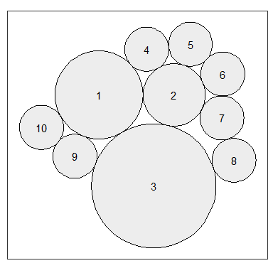

```r
dat.gg <- circleLayoutVertices(packing, npoints=50)

ggplot(data = dat.gg) + geom_polygon(aes(x, y, group = id), colour = "black",
fill = "grey90", alpha = 0.7, show.legend = FALSE) +

geom_text(data = packing, aes(x, y), label = 1:nrow(packing)) +

coord_equal()
```

By default, `circleProgressiveLayout` takes the input sizes to be circle areas. If instead you have input radii, add `sizetype = "radius"` to the arguments when calling the function.

## Layouts are order dependent

Re-ordering the input sizes will generally produce a different layout unless the sizes are uniform. Here we repeatedly shuffle the area values used above and generate a new layout each time.

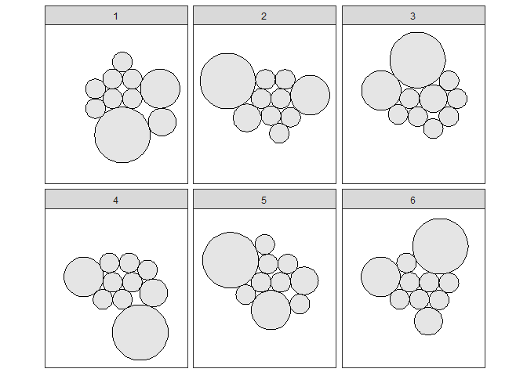

```r
ncircles <- length(areas)
nreps <- 6

packings <- lapply(
  1:nreps,
  function(i) {
    x <- sample(areas, ncircles)
    circleProgressiveLayout(x)
  })

packings <- do.call(rbind, packings)

npts <- 50
dat.gg <- circleLayoutVertices(packings, npoints = npts)

dat.gg$rep <- rep(1:nreps, each = ncircles * (npts+1))


ggplot(data = dat.gg, aes(x, y)) +
  geom_polygon(aes(group = id),
               colour = "black", fill = "grey90") +

  coord_equal() +

  facet_wrap(~ rep, nrow = 2)
```

We can use this ordering effect to create some circle art…

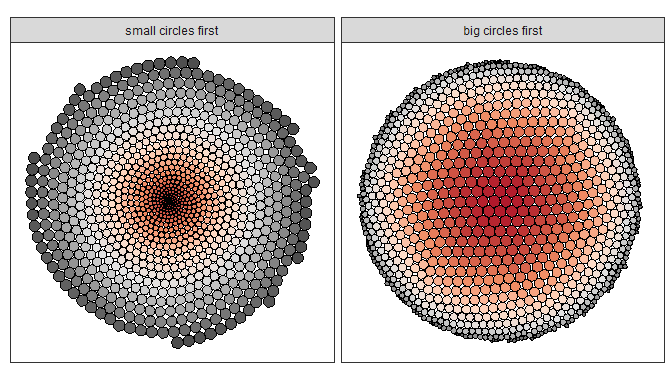

```r
areas <- 1:1000

# area: small to big
packing1 <- circleProgressiveLayout(areas)
dat1 <- circleLayoutVertices(packing1)

# area: big to small
packing2 <- circleProgressiveLayout( rev(areas) )
dat2 <- circleLayoutVertices(packing2)

dat <- rbind(
  cbind(dat1, set = 1),
  cbind(dat2, set = 2) )

ggplot(data = dat, aes(x, y)) +
  geom_polygon(aes(group = id, fill = -id),
               colour = "black", show.legend = FALSE) +

  scale_fill_distiller(palette = "RdGy") +

  coord_equal() +

  facet_wrap(~set,
             labeller = as_labeller(
               c('1' = "small circles first",
                 '2' = "big circles first"))
             )
```

## More detailed layout display

The package includes an example data set of the abundance of different types of bacteria measured in a study of biofilms. Columns are value (abundance), display colour and label (bacterial taxon).

```r
data("bacteria")
head(bacteria)
```

```
##   value  colour                                label
## 1  4232 #DDF379            Dehalogenimonas sp. WBC-2
## 2  5097 #F3C679 Desulfatibacillum alkenivorans AK-01
## 3  2825 #79F398               Opitutus terrae PB90-1
## 4  3471 #F3C679                            Geobacter
## 5  7515 #79F3EA        Methanosaeta harundinacea 6Ac
## 6  2476 #C4F379  Rubinisphaera brasiliensis DSM 5305
```

The following example shows how to display the abundance values as circles filled with the specified colours. It relies on the fact that the `id` column in the output of `circleLayoutVertices` maps to the row number of the input data.

Note: the y-axis is reversed so that the layour is rendered similarly to the example [here](https://github.com/pmenzel/packCircles).

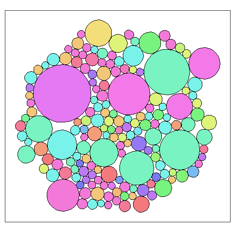

```r
packing <- circleProgressiveLayout(bacteria)

dat.gg <- circleLayoutVertices(packing)

ggplot(data = dat.gg) +
  geom_polygon(aes(x, y, group = id, fill = factor(id)),
               colour = "black",
               show.legend = FALSE) +

  scale_fill_manual(values = bacteria$colour) +

  scale_y_reverse() +

  coord_equal()
```

As a further flourish, we can make the plot interactive so that the name of the bacterial taxon is displayed when the mouse cursor hovers a circle. Here we use the `ggiraph` package to accomplish this.

```r
library(ggiraph)

gg <- ggplot(data = dat.gg) +

  geom_polygon_interactive(
    aes(x, y, group = id, fill = factor(id),
        tooltip = bacteria$label[id], data_id = id),
    colour = "black",
    show.legend = FALSE) +

  scale_fill_manual(values = bacteria$colour) +

  scale_y_reverse() +

  labs(title = "Hover over circle to display taxon name") +

  coord_equal()

ggiraph(ggobj = gg, width_svg = 5, height_svg = 5)
```

[interactive chart not shown]